# TITANIC PROJECT

## "🚢 Who Lived, Who Didn't: The Titanic Story Told in Charts"

"On April 10, 1912, the RMS Titanic embarked on its maiden voyage with over 2,200 passengers and crew on board. What began as a voyage of promise ended as one of the most infamous tragedies in maritime history. But hidden in the data are insights into who survived, who didn’t—and why."

In this project, we explore survival patterns using data visualization and storytelling. Through this lens, we aim to humanize the numbers and reveal the deeper forces at play.

🧭 2. About the Dataset: Briefly describe the titanic dataset from Seaborn:

- 891 passengers
- Features: age, class, sex, fare, embarkation point, and survival status
- Loaded using sns.load_dataset("titanic")

```python
import matplotlib.pyplot as plt
import seaborn as sns
import pandas as pd

df = sns.load_dataset("titanic")  # ✅ Apply .head(40) after loading
df.head(50)
```

|  | survived | pclass | sex | age | sibsp | parch | fare | embarked | class | who | adult_male | deck | embark_town | alive | alone |
| --- | --- | --- | --- | --- | --- | --- | --- | --- | --- | --- | --- | --- | --- | --- | --- |
| 0 | 0 | 3 | male | 22.0 | 1 | 0 | 7.2500 | S | Third | man | True | NaN | Southampton | no | False |
| 1 | 1 | 1 | female | 38.0 | 1 | 0 | 71.2833 | C | First | woman | False | C | Cherbourg | yes | False |
| 2 | 1 | 3 | female | 26.0 | 0 | 0 | 7.9250 | S | Third | woman | False | NaN | Southampton | yes | True |
| 3 | 1 | 1 | female | 35.0 | 1 | 0 | 53.1000 | S | First | woman | False | C | Southampton | yes | False |
| 4 | 0 | 3 | male | 35.0 | 0 | 0 | 8.0500 | S | Third | man | True | NaN | Southampton | no | True |
| 5 | 0 | 3 | male | NaN | 0 | 0 | 8.4583 | Q | Third | man | True | NaN | Queenstown | no | True |
| 6 | 0 | 1 | male | 54.0 | 0 | 0 | 51.8625 | S | First | man | True | E | Southampton | no | True |
| 7 | 0 | 3 | male | 2.0 | 3 | 1 | 21.0750 | S | Third | child | False | NaN | Southampton | no | False |
| 8 | 1 | 3 | female | 27.0 | 0 | 2 | 11.1333 | S | Third | woman | False | NaN | Southampton | yes | False |
| 9 | 1 | 2 | female | 14.0 | 1 | 0 | 30.0708 | C | Second | child | False | NaN | Cherbourg | yes | False |
| 10 | 1 | 3 | female | 4.0 | 1 | 1 | 16.7000 | S | Third | child | False | G | Southampton | yes | False |
| 11 | 1 | 1 | female | 58.0 | 0 | 0 | 26.5500 | S | First | woman | False | C | Southampton | yes | True |
| 12 | 0 | 3 | male | 20.0 | 0 | 0 | 8.0500 | S | Third | man | True | NaN | Southampton | no | True |
| 13 | 0 | 3 | male | 39.0 | 1 | 5 | 31.2750 | S | Third | man | True | NaN | Southampton | no | False |
| 14 | 0 | 3 | female | 14.0 | 0 | 0 | 7.8542 | S | Third | child | False | NaN | Southampton | no | True |
| 15 | 1 | 2 | female | 55.0 | 0 | 0 | 16.0000 | S | Second | woman | False | NaN | Southampton | yes | True |
| 16 | 0 | 3 | male | 2.0 | 4 | 1 | 29.1250 | Q | Third | child | False | NaN | Queenstown | no | False |
| 17 | 1 | 2 | male | NaN | 0 | 0 | 13.0000 | S | Second | man | True | NaN | Southampton | yes | True |
| 18 | 0 | 3 | female | 31.0 | 1 | 0 | 18.0000 | S | Third | woman | False | NaN | Southampton | no | False |
| 19 | 1 | 3 | female | NaN | 0 | 0 | 7.2250 | C | Third | woman | False | NaN | Cherbourg | yes | True |
| 20 | 0 | 2 | male | 35.0 | 0 | 0 | 26.0000 | S | Second | man | True | NaN | Southampton | no | True |
| 21 | 1 | 2 | male | 34.0 | 0 | 0 | 13.0000 | S | Second | man | True | D | Southampton | yes | True |
| 22 | 1 | 3 | female | 15.0 | 0 | 0 | 8.0292 | Q | Third | child | False | NaN | Queenstown | yes | True |
| 23 | 1 | 1 | male | 28.0 | 0 | 0 | 35.5000 | S | First | man | True | A | Southampton | yes | True |
| 24 | 0 | 3 | female | 8.0 | 3 | 1 | 21.0750 | S | Third | child | False | NaN | Southampton | no | False |
| 25 | 1 | 3 | female | 38.0 | 1 | 5 | 31.3875 | S | Third | woman | False | NaN | Southampton | yes | False |
| 26 | 0 | 3 | male | NaN | 0 | 0 | 7.2250 | C | Third | man | True | NaN | Cherbourg | no | True |
| 27 | 0 | 1 | male | 19.0 | 3 | 2 | 263.0000 | S | First | man | True | C | Southampton | no | False |
| 28 | 1 | 3 | female | NaN | 0 | 0 | 7.8792 | Q | Third | woman | False | NaN | Queenstown | yes | True |
| 29 | 0 | 3 | male | NaN | 0 | 0 | 7.8958 | S | Third | man | True | NaN | Southampton | no | True |
| 30 | 0 | 1 | male | 40.0 | 0 | 0 | 27.7208 | C | First | man | True | NaN | Cherbourg | no | True |
| 31 | 1 | 1 | female | NaN | 1 | 0 | 146.5208 | C | First | woman | False | B | Cherbourg | yes | False |
| 32 | 1 | 3 | female | NaN | 0 | 0 | 7.7500 | Q | Third | woman | False | NaN | Queenstown | yes | True |
| 33 | 0 | 2 | male | 66.0 | 0 | 0 | 10.5000 | S | Second | man | True | NaN | Southampton | no | True |
| 34 | 0 | 1 | male | 28.0 | 1 | 0 | 82.1708 | C | First | man | True | NaN | Cherbourg | no | False |
| 35 | 0 | 1 | male | 42.0 | 1 | 0 | 52.0000 | S | First | man | True | NaN | Southampton | no | False |
| 36 | 1 | 3 | male | NaN | 0 | 0 | 7.2292 | C | Third | man | True | NaN | Cherbourg | yes | True |
| 37 | 0 | 3 | male | 21.0 | 0 | 0 | 8.0500 | S | Third | man | True | NaN | Southampton | no | True |
| 38 | 0 | 3 | female | 18.0 | 2 | 0 | 18.0000 | S | Third | woman | False | NaN | Southampton | no | False |
| 39 | 1 | 3 | female | 14.0 | 1 | 0 | 11.2417 | C | Third | child | False | NaN | Cherbourg | yes | False |
| 40 | 0 | 3 | female | 40.0 | 1 | 0 | 9.4750 | S | Third | woman | False | NaN | Southampton | no | False |
| 41 | 0 | 2 | female | 27.0 | 1 | 0 | 21.0000 | S | Second | woman | False | NaN | Southampton | no | False |
| 42 | 0 | 3 | male | NaN | 0 | 0 | 7.8958 | C | Third | man | True | NaN | Cherbourg | no | True |
| 43 | 1 | 2 | female | 3.0 | 1 | 2 | 41.5792 | C | Second | child | False | NaN | Cherbourg | yes | False |
| 44 | 1 | 3 | female | 19.0 | 0 | 0 | 7.8792 | Q | Third | woman | False | NaN | Queenstown | yes | True |
| 45 | 0 | 3 | male | NaN | 0 | 0 | 8.0500 | S | Third | man | True | NaN | Southampton | no | True |
| 46 | 0 | 3 | male | NaN | 1 | 0 | 15.5000 | Q | Third | man | True | NaN | Queenstown | no | False |
| 47 | 1 | 3 | female | NaN | 0 | 0 | 7.7500 | Q | Third | woman | False | NaN | Queenstown | yes | True |
| 48 | 0 | 3 | male | NaN | 2 | 0 | 21.6792 | C | Third | man | True | NaN | Cherbourg | no | False |
| 49 | 0 | 3 | female | 18.0 | 1 | 0 | 17.8000 | S | Third | woman | False | NaN | Southampton | no | False |

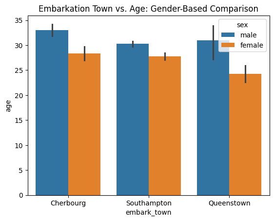

```python
order_1=["Cherbourg","Southampton","Queenstown"]
sns.barplot(y="age", x="embark_town", hue="sex", data=df,order=order_1,errorbar=("ci",50))
plt.title("Embarkation Town vs. Age: Gender-Based Comparison")
plt.show()
```